# Machine Learning Essentials SS25 - Exercise Sheet 6

## Instructions

- `TODO`'s indicate where you need to complete the implementations.
- You may use external resources, but **write your own solutions**.
- Provide concise, but comprehensible comments to explain what your code does.
- Code that's unnecessarily extensive and/or not well commented will not be scored.

```python
import matplotlib.pyplot as plt
import numpy as np
import torch as tc
import torch.nn as nn
import torch.optim as optim
from torch.utils.data import Dataset
from torch.utils.data import DataLoader
from torchsummary import summary

np.random.seed(42)
tc.manual_seed(42)

device = tc.device("cuda" if tc.cuda.is_available() else "cpu")
```

## Exercise 2 - CNN Classifier

The SIGNS dataset is a collection of 6 signs representing numbers from 0 to 5. We first load the data and have the shapes printed out. The split into train, validation and test set has already been carried out.

```python
# Load the dataset
X_train = np.load('sign_data/X_train.npy')
Y_train = np.load('sign_data/Y_train.npy')
X_val = np.load('sign_data/X_val.npy')
Y_val = np.load('sign_data/Y_val.npy')
X_test = np.load('sign_data/X_test.npy')
Y_test = np.load('sign_data/Y_test.npy')

# print the shape of the dataset
print("X_train shape: " + str(X_train.shape))
print("Y_train shape: " + str(Y_train.shape))
print("X_val shape: " + str(X_val.shape))
print("Y_val shape: " + str(Y_val.shape))
print("X_test shape: " + str(X_test.shape))
print("Y_test shape: " + str(Y_test.shape)+"\n")
print("classes: " + str(np.unique(Y_train)))

# check if classes are balanced
print("Counts of classes in Y_train: " + str(np.unique(Y_train, return_counts=True)[1]))
print("Counts of classes in Y_val: " + str(np.unique(Y_val, return_counts=True)[1]))
print("Counts of classes in Y_test: " + str(np.unique(Y_test, return_counts=True)[1]))
```

```
X_train shape: (960, 64, 64, 3)
Y_train shape: (960,)
X_val shape: (120, 64, 64, 3)
Y_val shape: (120,)
X_test shape: (120, 64, 64, 3)
Y_test shape: (120,)

classes: [0 1 2 3 4 5]
Counts of classes in Y_train: [160 160 160 160 160 160]
Counts of classes in Y_val: [20 20 20 20 20 20]
Counts of classes in Y_test: [20 20 20 20 20 20]
```

The classes are balanced so that accuracy is an appropriate measure for evaluating a classifier. We next visualize an instance of each class.

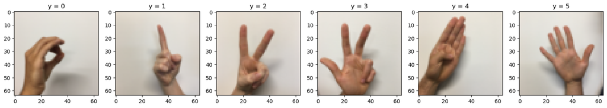

```python
fig, axs = plt.subplots(1, 6, figsize=(20, 10))
for i in range(6):
    # get indices where the label is i
    idx = np.where(Y_train == i)[0][0]
    axs[i].imshow(X_train[idx])
    axs[i].set_title("y = " + str(i))
```

Pixels in each channel (RGB) of the images take values in the range [0, 255]. However, it is desirable to have absolute values in the range [0, 1] as input for neural network architectures to avoid exploding or vanishing gradient problems. Through the following cell, we apply a simple data scaling procedure: we divide the values of the pixels by 255. As an alternative, you can use the `StandardScaler()` function of the scikit-learn library.

```python
X_train = X_train/255
X_val = X_val/255
X_test = X_test/255
```

### Task 1

Use pytorch to build the model. Take a look at the [documentation](https://pytorch.org/tutorials/beginner/basics/intro.html) for an introduction, a detailed tutorial, for example for classifiers, can be found [here](https://pytorch.org/tutorials/beginner/blitz/cifar10_tutorial.html).

Implement the following architecture:

```
 - Conv2d: 4 output channels, 3 by 3 filter size, stride 1, padding "same"
 - BatchNorm2d: 4 output channels
 - ReLU activation
 - MaxPool2d: 2 by 2 filter size, stride 2, padding 0
 - Conv2d: 8 output channels, 3 by 3 filter size, stride 1, padding "same"
 - BatchNorm2d: 8 output channels
 - ReLU activation
 - MaxPool2d: Use a 2 by 2 filter size, stride 2, padding 0
 - Flatten the previous output
 - Linear: 64 output neurons
 - ReLu activation function
 - Linear: 6 output neurons
 - LogSoftmax
```

We use the [LogSoftmax](https://pytorch.org/docs/stable/generated/torch.nn.LogSoftmax.html) here instead of the Softmax for computational reasons. Accordingly, the loss function is not CrossEntropyLoss but NLLLoss. When flattening, be careful not to do it with the batch dimension but only with the height, width and channel dimension.

```python
class CNN_Classifier(nn.Module):
    def __init__(self):
        super().__init__()

        # TODO: Initialize the layers of the CNN

        # First convolutional block
        self.conv1 = nn.Conv2d(3, 4, kernel_size=3, stride=1, padding='same')
        self.bn1 = nn.BatchNorm2d(4)
        self.relu1 = nn.ReLU()
        self.pool1 = nn.MaxPool2d(kernel_size=2, stride=2, padding=0)

        # Second convolutional block
        self.conv2 = nn.Conv2d(4, 8, kernel_size=3, stride=1, padding='same')
        self.bn2 = nn.BatchNorm2d(8)
        self.relu2 = nn.ReLU()
        self.pool2 = nn.MaxPool2d(kernel_size=2, stride=2, padding=0)

        # Flatten layer
        self.flatten = nn.Flatten()

        # Fully connected layers
        # After two 2x2 max pooling operations, 64x64 -> 32x32 -> 16x16
        # So we have 8 channels * 16 * 16 = 2048 features
        self.fc1 = nn.Linear(8 * 16 * 16, 64)
        self.relu3 = nn.ReLU()
        self.fc2 = nn.Linear(64, 6)
        self.logsoftmax = nn.LogSoftmax(dim=1)


    def forward(self, X):
        # TODO: Implement the forward pass
        # First convolutional block
        X = self.conv1(X)
        X = self.bn1(X)
        X = self.relu1(X)
        X = self.pool1(X)

        # Second convolutional block
        X = self.conv2(X)
        X = self.bn2(X)
        X = self.relu2(X)
        X = self.pool2(X)

        # Flatten and fully connected layers
        X = self.flatten(X)
        X = self.fc1(X)
        X = self.relu3(X)
        X = self.fc2(X)
        X = self.logsoftmax(X)

        return X
```

To test your model you can foward some random numbers. The shape of the output should be (2, 6).

```python
cnn_model = CNN_Classifier()
# dummy sample of batch size 2
X_random = tc.randn(2, 3, 64, 64)
output = cnn_model(X_random)

print("Output shape: " + str(output.shape))
```

```
Output shape: torch.Size([2, 6])
```

torchsummary.summary provides a nice overview of the model and the number of learnable parameters:

```python
summary(cnn_model, input_size=(3, 64, 64), device="cpu")
```

```
=================================================================
Layer (type:depth-idx)                   Param #
=================================================================
├─Conv2d: 1-1                            112
├─BatchNorm2d: 1-2                       8
├─ReLU: 1-3                              --
├─MaxPool2d: 1-4                         --
├─Conv2d: 1-5                            296
├─BatchNorm2d: 1-6                       16
├─ReLU: 1-7                              --
├─MaxPool2d: 1-8                         --
├─Flatten: 1-9                           --
├─Linear: 1-10                           131,136
├─ReLU: 1-11                             --
├─Linear: 1-12                           390
├─LogSoftmax: 1-13                       --
=================================================================
Total params: 131,958
Trainable params: 131,958
Non-trainable params: 0
=================================================================
```

[output not shown]

### Task 2

DataLoaders wrap around Datasets to provide efficient data batching, shuffling, and parallel loading during model training or inference. To define a custom dataset we must implement three functions: **init**, **len** and **get_item**. While **len** defines the length of the dataset and thus the number of batches in the dataloader, **get_item** can be used to get a single sample through the index.

```python
class Image_Dataset(Dataset):
    def __init__(self, X, Y):
        self.X = X
        self.Y = Y

    def __len__(self):
        # TODO: Return the length of the dataset
        return len(self.X)


    def __getitem__(self, idx):
        # TODO: Return the image as a float tensor and the label as a long tensor
        # Images need to be transposed from (H, W, C) to (C, H, W) for PyTorch
        image = tc.tensor(self.X[idx].transpose(2, 0, 1), dtype=tc.float32)
        label = tc.tensor(self.Y[idx], dtype=tc.long)
        return image, label
```

```python
train_batch_size = 64
val_batch_size = len(Y_val)
test_batch_size = len(Y_test)

# TODO: Create the dataset and dataloader
train_dataset = Image_Dataset(X_train, Y_train)
val_dataset = Image_Dataset(X_val, Y_val)
test_dataset = Image_Dataset(X_test, Y_test)

train_loader = DataLoader(train_dataset, batch_size=train_batch_size, shuffle=True)
val_loader = DataLoader(val_dataset, batch_size=val_batch_size, shuffle=False)
test_loader = DataLoader(test_dataset, batch_size=test_batch_size, shuffle=False)
```

To make sure that everything has worked properly, we take a sample of the data_loader and visualize it.

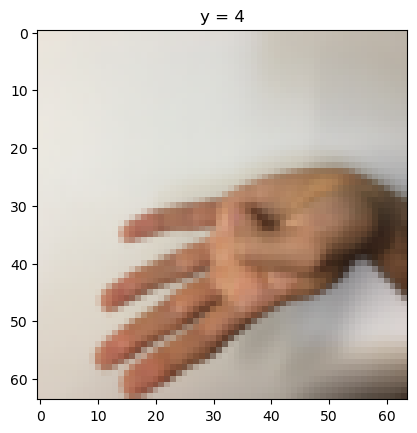

```python
sample_X, sample_Y = next(iter(train_loader))
plt.imshow(sample_X[0].T)
plt.title("y = " + str(int(sample_Y[0].item())))
plt.show()
```

### Task 3

Implement the training loop. Use the negative log-likelihood loss (NLLLoss) and the Adam optimizer. Be sure to zero the gradients after each optimization step to avoid accumulating contributions from previous epochs and batches.

```python
def train_cnn(model, train_loader, val_loader, lr, n_epochs, device):
    model = model.to(device)

    # TODO: Initialize the optimizer and loss function
    loss_function = nn.NLLLoss()
    optimizer = optim.Adam(model.parameters(), lr=lr)

    train_loss = np.zeros(n_epochs)
    val_loss = np.zeros(n_epochs)
    train_acc = np.zeros(n_epochs)
    val_acc = np.zeros(n_epochs)

    for epoch in range(1, n_epochs + 1):
        model.train()

        epoch_loss = 0

        for X, Y in train_loader:
            X, Y = X.to(device), Y.to(device)
            # TODO: Implement the training loop
            optimizer.zero_grad()
            output = model(X)
            loss = loss_function(output, Y)
            loss.backward()
            optimizer.step()

            epoch_loss += loss.item()/len(train_loader)

        train_loss[epoch - 1] = epoch_loss
        train_acc[epoch - 1] = (output.argmax(dim=1) == Y).float().mean().item()

        model.eval()

        with tc.no_grad():
            X, Y = next(iter(val_loader))
            X, Y = X.to(device), Y.to(device)
            # TODO: Implement the evaluation step
            output = model(X)
            loss = loss_function(output, Y)

            val_loss[epoch - 1] = loss.item()
            val_acc[epoch - 1] = (output.argmax(dim=1) == Y).float().mean().item()
        print(f"Epoch {epoch}/{n_epochs} - Train Loss: {epoch_loss:.4f}, Test Loss: {loss.item():.4f}")

    return train_loss, val_loss, train_acc, val_acc
```

```python
n_epochs = 50
# TODO: Train the model with different learning rates
learning_rates = [1e-1, 1e-3, 1e-4, 1e-5]
results = {}

for lr in learning_rates:
    print(f"\nTraining with learning rate: {lr}")
    model = CNN_Classifier()
    train_loss, val_loss, train_acc, val_acc = train_cnn(
        model, train_loader, val_loader, lr, n_epochs, device
    )
    results[lr] = {
        'model': model,
        'train_loss': train_loss,
        'val_loss': val_loss,
        'train_acc': train_acc,
        'val_acc': val_acc
    }
```

[output not shown]

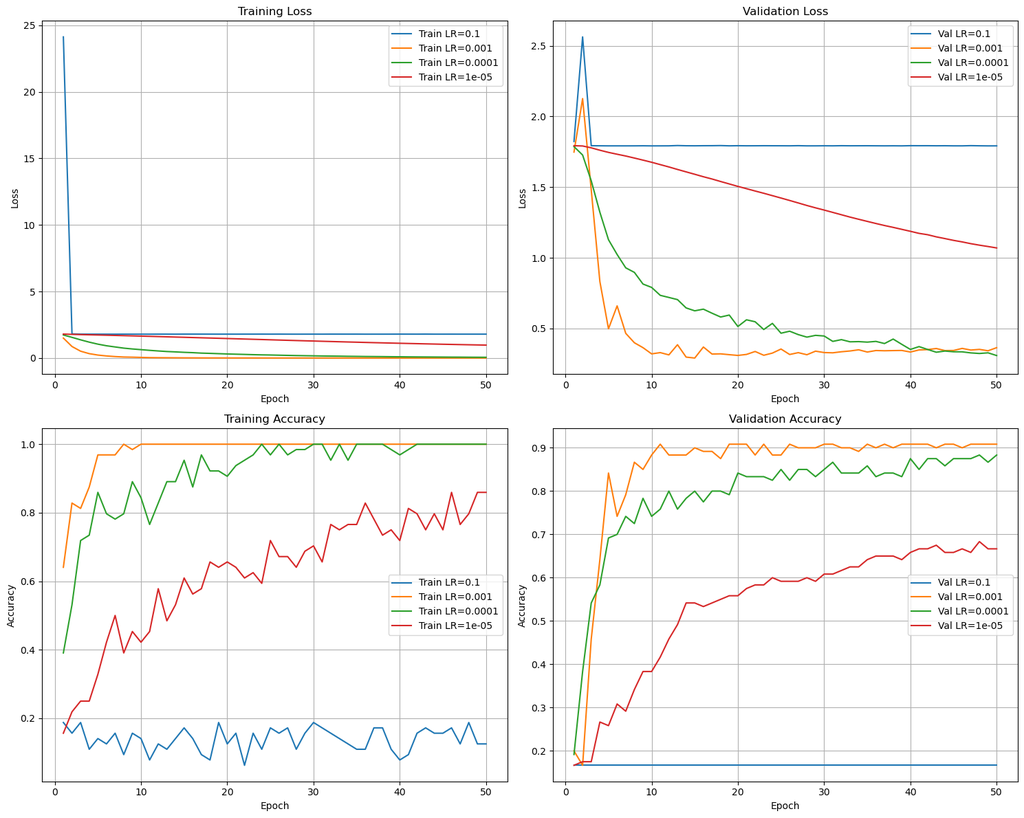

```python
# TODO: Visualize the results
fig, axes = plt.subplots(2, 2, figsize=(15, 12))

for lr in learning_rates:
    epochs = range(1, n_epochs + 1)

    # Plot losses
    axes[0, 0].plot(epochs, results[lr]['train_loss'], label=f'Train LR={lr}')
    axes[0, 1].plot(epochs, results[lr]['val_loss'], label=f'Val LR={lr}')

    # Plot accuracies
    axes[1, 0].plot(epochs, results[lr]['train_acc'], label=f'Train LR={lr}')
    axes[1, 1].plot(epochs, results[lr]['val_acc'], label=f'Val LR={lr}')

axes[0, 0].set_title('Training Loss')
axes[0, 0].set_xlabel('Epoch')
axes[0, 0].set_ylabel('Loss')
axes[0, 0].legend()
axes[0, 0].grid(True)

axes[0, 1].set_title('Validation Loss')
axes[0, 1].set_xlabel('Epoch')
axes[0, 1].set_ylabel('Loss')
axes[0, 1].legend()
axes[0, 1].grid(True)

axes[1, 0].set_title('Training Accuracy')
axes[1, 0].set_xlabel('Epoch')
axes[1, 0].set_ylabel('Accuracy')
axes[1, 0].legend()
axes[1, 0].grid(True)

axes[1, 1].set_title('Validation Accuracy')
axes[1, 1].set_xlabel('Epoch')
axes[1, 1].set_ylabel('Accuracy')
axes[1, 1].legend()
axes[1, 1].grid(True)

plt.tight_layout()
plt.show()
```

- A learning rate of 0.001 seems to be the most effective among the tested values, providing a good balance between convergence speed and generalization performance.
- A learning rate of 0.1 is too high, leading to poor performance.
- Learning rates of 0.0001 and 0.00001 are too low, resulting in slow convergence.
- The model is able to achieve a validation accuracy of around 90% with the optimal learning rate of 0.001, indicating good generalization to unseen data.

### Task 4

```python
# TODO: apply the best model to the test set
best_lr = max(learning_rates, key=lambda lr: results[lr]['val_acc'][-1])
best_model = results[best_lr]['model']

print(f"\nBest learning rate: {best_lr}")
print(f"Best validation accuracy: {results[best_lr]['val_acc'][-1]:.4f}")

# Test the best model
best_model.eval()
with tc.no_grad():
    X_test_tensor, Y_test_tensor = next(iter(test_loader))
    X_test_tensor, Y_test_tensor = X_test_tensor.to(device), Y_test_tensor.to(device)

    test_output = best_model(X_test_tensor)
    test_acc = (test_output.argmax(dim=1) == Y_test_tensor).float().mean().item()

    print(f"Test accuracy: {test_acc:.4f}")
    print(f"Difference from validation accuracy: {abs(test_acc - results[best_lr]['val_acc'][-1]):.4f}")
```

```
Best learning rate: 0.001
Best validation accuracy: 0.9083
Test accuracy: 0.8917
Difference from validation accuracy: 0.0167
```